# Simulations in R Part 2 - Bootstrapping & Simulating Bivariate and Multivariate Distributions

Patrick Ward

7/6/2023

## Resampling

**Bootstrap**

The general concept of bootstrapping is as follows:

- Draw multiple random samples from observed data with replacement.
- Draws must be independent and each observation must have an equal chance of being selected.
- The bootstrap sample should be the same size as the observed data in order to use as much information from the sample as possible.
- Calculate the mean resampled data and store it.
- Repeat this process thousands of times and summarize the mean of resampled means and the standard deviation of resampled means to obtain summary statistics of your bootstrapped resamples.

**Write the bootstrap resampling by hand**

```r
library(tidyverse)
## create fake data
dat <- c(5, 10, 44, 3, 29, 10, 16.7, 22.3, 28, 1.4, 25)

### Bootstrap Resamples ###
# we want 1000 bootstrap resamples
n_boots <- 1000

## create an empty vector to store our bootstraps
boot_dat <- rep(NA, n_boots)

# set seed for reproducibility
set.seed(786)

# write for() loop for the resampling
for(i in 1:n_boots){
  # random sample of 1:n number of observations in our data, with replacement
  ind <- sample(1:length(dat), replace = TRUE)

  # Use the row indexes to select the given values from the vector and calculate the mean
  boot_dat[i] <- mean(dat[ind])
}

# Look at the first 6 bootstrapped means
head(boot_dat)
```

```
## [1] 16.00909 17.98182 20.49091 18.72727 23.81818 17.52727
```

```r
### Compare Bootstrap data to original data ###
## mean and standard deviation of the fake data
dat_mean <- mean(dat)
dat_sd <- sd(dat)

# standard error of the mean
dat_se <- sd(dat) / sqrt(length(dat))

# 95% confidence interval
dat_ci95 <- paste0(round(dat_mean - 1.96*dat_se, 1), ", ", round(dat_mean + 1.96*dat_se, 1))

# mean an SD of bootstrapped data
boot_mean <- mean(boot_dat)

# the vector is the mean of each bootstrap sample, so the standard deviation of these means represents the standard error
boot_se <- sd(boot_dat)

# to get the standard deviation we can convert the standard error back
boot_sd <- boot_se * sqrt(length(dat))

# 95% quantile interval
boot_ci95 <- paste0(round(boot_mean - 1.96*boot_se, 1), ", ", round(boot_mean + 1.96*boot_se, 1))

## Put everything together
data.frame(data = c("fake sample", "bootstrapped resamples"),
           N = c(length(dat), length(boot_dat)),
           mean = c(dat_mean, boot_mean),
           sd = c(dat_sd, boot_sd),
           se = c(dat_se, boot_se),
           ci95 = c(dat_ci95, boot_ci95)) %>%
  knitr::kable()
```

| data | N | mean | sd | se | ci95 |
| --- | --- | --- | --- | --- | --- |
| fake sample | 11 | 17.67273 | 13.27615 | 4.002910 | 9.8, 25.5 |
| bootstrapped resamples | 1000 | 17.81579 | 12.22947 | 3.687324 | 10.6, 25 |

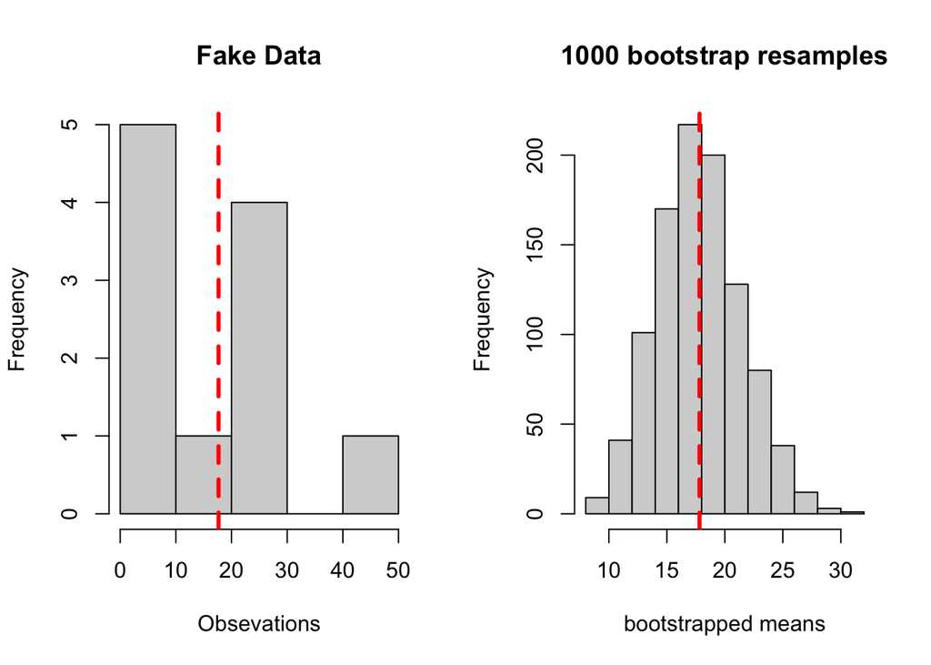

```r
# plot the distributions
par(mfrow = c(1, 2))
hist(dat,
     xlab = "Obsevations",
     main = "Fake Data")
abline(v = dat_mean,
       col = "red",
       lwd = 3,
       lty = 2)
hist(boot_dat,
     xlab = "bootstrapped means",
     main = "1000 bootstrap resamples")
abline(v = boot_mean,
       col = "red",
       lwd = 3,
       lty = 2)
```

R offers a bootstrap function from the `boot` package that allows you to do the same thing without writing out your own `for()` loop.

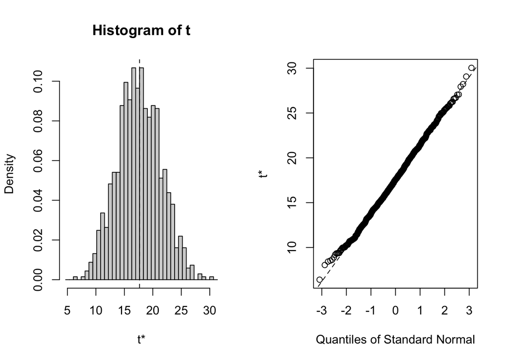

```r
# write a function to calculate the mean of our sample data
sample_mean <- function(x, d){
     return(mean(x[d]))
}

# run the boot() function
library(boot)

# run the boot function
boot_func_output <- boot(dat, statistic = sample_mean, R = 1000)

# produce a plot of the output
plot(boot_func_output)
```

```r
# get the mean and standard error
boot_func_output
```

```
##
## ORDINARY NONPARAMETRIC BOOTSTRAP
##
##
## Call:
## boot(data = dat, statistic = sample_mean, R = 1000)
##
##
## Bootstrap Statistics :
##     original      bias    std. error
## t1* 17.67273 -0.06269091    3.801365
```

```r
# get 95% CI around the mean
boot.ci(boot_func_output, type = "basic", conf = 0.95)
```

```
## BOOTSTRAP CONFIDENCE INTERVAL CALCULATIONS
## Based on 1000 bootstrap replicates
##
## CALL :
## boot.ci(boot.out = boot_func_output, conf = 0.95, type = "basic")
##
## Intervals :
## Level      Basic
## 95%   (10.20, 25.04 )
## Calculations and Intervals on Original Scale
```

We can bootstrap pretty much anything we want. We don’t have to limit ourselves to producing the distribution around the mean of a population. For example, let’s bootstrap regression coefficients to understand the uncertainty in them.

First, let’s use the `boot()` function to conduct our analysis.

```r
# load the mtcars data
d <- mtcars
d %>%
  head()
```

```
##                    mpg cyl disp  hp drat    wt  qsec vs am gear carb
## Mazda RX4         21.0   6  160 110 3.90 2.620 16.46  0  1    4    4
## Mazda RX4 Wag     21.0   6  160 110 3.90 2.875 17.02  0  1    4    4
## Datsun 710        22.8   4  108  93 3.85 2.320 18.61  1  1    4    1
## Hornet 4 Drive    21.4   6  258 110 3.08 3.215 19.44  1  0    3    1
## Hornet Sportabout 18.7   8  360 175 3.15 3.440 17.02  0  0    3    2
## Valiant           18.1   6  225 105 2.76 3.460 20.22  1  0    3    1
```

```r
# fit a regression model
fit_mpg <- lm(mpg ~ wt, data = d)
summary(fit_mpg)
```

```
##
## Call:
## lm(formula = mpg ~ wt, data = d)
##
## Residuals:
##     Min      1Q  Median      3Q     Max
## -4.5432 -2.3647 -0.1252  1.4096  6.8727
##
## Coefficients:
##             Estimate Std. Error t value Pr(>|t|)
## (Intercept)  37.2851     1.8776  19.858  < 2e-16 ***
## wt           -5.3445     0.5591  -9.559 1.29e-10 ***
## ---
## Signif. codes:  0 '***' 0.001 '**' 0.01 '*' 0.05 '.' 0.1 ' ' 1
##
## Residual standard error: 3.046 on 30 degrees of freedom
## Multiple R-squared:  0.7528, Adjusted R-squared:  0.7446
## F-statistic: 91.38 on 1 and 30 DF,  p-value: 1.294e-10
```

```r
coef(fit_mpg)
```

```
## (Intercept)          wt
##   37.285126   -5.344472
```

```r
confint(fit_mpg)
```

```
##                 2.5 %    97.5 %
## (Intercept) 33.450500 41.119753
## wt          -6.486308 -4.202635
```

```r
# Write a function that can perform a bootstrap over the intercept and slope of the model
# bootstrap function
reg_coef_boot <- function(data, row_id){
  # we want to resample the rows
  fit <- lm(mpg ~ wt, data = d[row_id, ])
  coef(fit)
}

# run this once on a small subset of the row ids to see how it works
reg_coef_boot(data = d, row_id = 1:20)
```

```
## (Intercept)          wt
##   38.517005   -5.410409
```

```r
# run the boot() function 1000 times
coef_boot <- boot(data = d,
          reg_coef_boot,
          1000)

# check the output (coefficient and SE)
coef_boot
```

```
##
## ORDINARY NONPARAMETRIC BOOTSTRAP
##
##
## Call:
## boot(data = d, statistic = reg_coef_boot, R = 1000)
##
##
## Bootstrap Statistics :
##      original      bias    std. error
## t1* 37.285126  0.17026120   2.3669149
## t2* -5.344472 -0.06734113   0.7197792
```

```r
# get the confidence intervals
boot.ci(coef_boot, index= 2)
```

```
## BOOTSTRAP CONFIDENCE INTERVAL CALCULATIONS
## Based on 1000 bootstrap replicates
##
## CALL :
## boot.ci(boot.out = coef_boot, index = 2)
##
## Intervals :
## Level      Normal              Basic
## 95%   (-6.688, -3.866 )   (-6.456, -3.635 )
##
## Level     Percentile            BCa
## 95%   (-7.054, -4.233 )   (-6.961, -4.132 )
## Calculations and Intervals on Original Scale
```

```r
# all 1000 of the bootstrap resamples can be called
coef_boot$t %>%
  head()
```

```
##          [,1]      [,2]
## [1,] 36.52000 -5.182893
## [2,] 33.99375 -4.374812
## [3,] 35.01943 -4.951562
## [4,] 39.12012 -5.937709
## [5,] 39.72878 -6.170682
## [6,] 40.63244 -6.003130
```

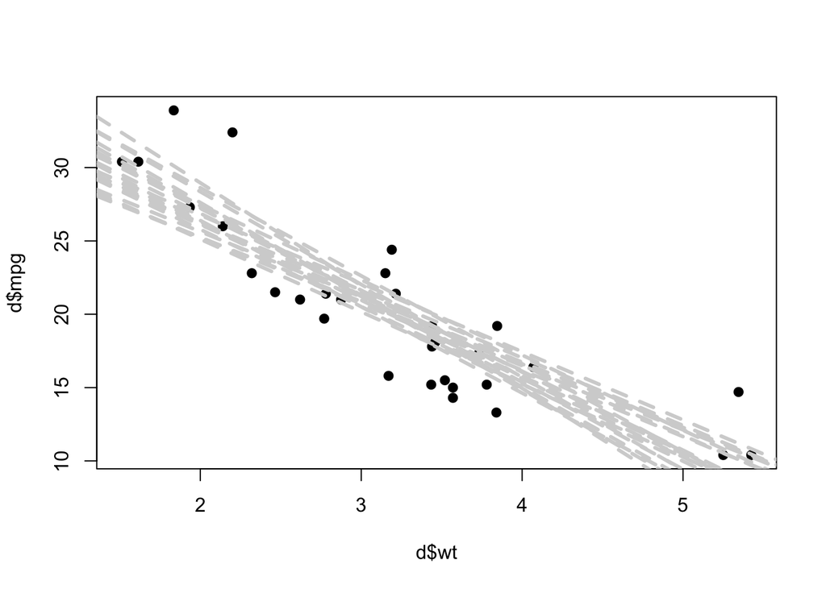

```r
# plot the first 20 bootstrapped intercepts and slopes over the original data
plot(x = d$wt,
     y = d$mpg,
     pch = 19)
for(i in 1:20){
  abline(a = coef_boot$t[i, 1],
       b = coef_boot$t[i, 2],
       lty = 2,
       lwd = 3,
       col = "light grey")
}
```

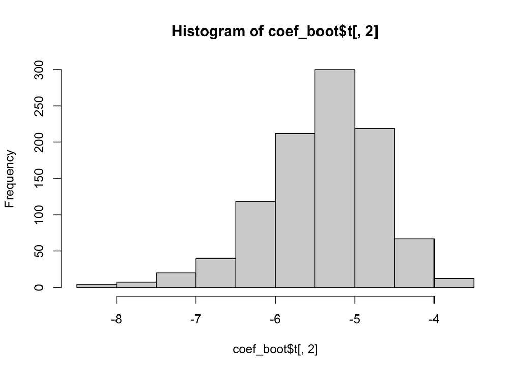

```r
## histogram of the slope coefficient
hist(coef_boot$t[, 2])
```

We can do this by hand if we don’t want to use the built in `boot()` function.

```r
## 1000 resamples
n_samples <- 1000

## N observations
n_obs <- nrow(mtcars)

## empty storage data frame for the coefficients
coef_storage <- data.frame(
  intercept = rep(NA, n_samples),
  slope = rep(NA, n_samples)
)

for(i in 1:n_samples){

  ## sample dependent and independent variables
  row_ids <- sample(1:n_obs, size = n_obs, replace = TRUE)
  new_df <- d[row_ids, ]

  ## construct model
  model <- lm(mpg ~ wt, data = new_df)

  ## store coefficients
  # intercept
  coef_storage[i, 1] <- coef(model)[1]

  # slope
  coef_storage[i, 2] <- coef(model)[2]

}

## see results
head(coef_storage)
```

```
##   intercept     slope
## 1  38.32066 -5.619573
## 2  38.53370 -5.538917
## 3  40.03748 -6.291180
## 4  37.99419 -5.571722
## 5  37.09325 -5.258876
## 6  37.80163 -5.332902
```

```r
tail(coef_storage)
```

```
##      intercept     slope
## 995   35.61412 -4.875757
## 996   34.54902 -4.594135
## 997   34.99077 -4.839503
## 998   35.58277 -4.782289
## 999   35.40989 -4.570279
## 1000  42.54493 -6.928372
```

```r
## Compare the results to those of the boot function
apply(X = coef_boot$t, MARGIN = 2, FUN = mean)
```

```
## [1] 37.455387 -5.411813
```

```r
apply(X = coef_storage, MARGIN = 2, FUN = mean)
```

```
## intercept     slope
## 37.395631 -5.404466
```

```r
apply(X = coef_boot$t, MARGIN = 2, FUN = sd)
```

```
## [1] 2.3669149 0.7197792
```

```r
apply(X = coef_storage, MARGIN = 2, FUN = sd)
```

```
## intercept     slope
## 2.2996887 0.6929343
```

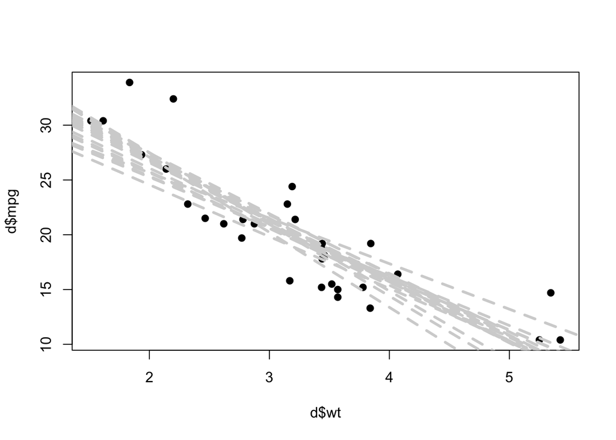

```r
## plot first 20 lines
plot(x = d$wt,
     y = d$mpg,
     pch = 19)
for(i in 1:20){
  abline(a = coef_storage[i, 1],
       b = coef_storage[i, 2],
       lty = 2,
       lwd = 3,
       col = "light grey")
}
```

## Simulating a relationship between two variables

As discussed before, simulation differs from resampling in that we use the parameters of the observed data to compute a new distribution, versus sampling from the data we have on hand.

For example, using the mean and standard deviation of `mpg` from the `mtcars` data set, we can simulate 1000 random draws from a normal distribution.

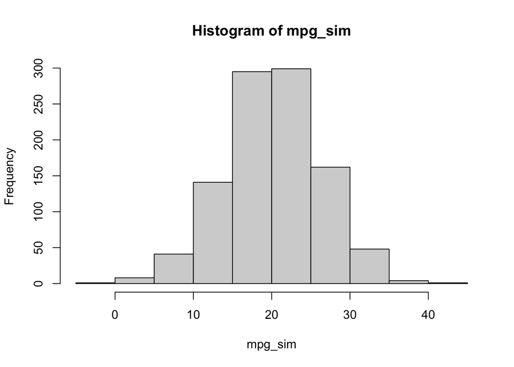

```r
## load the mtcars data set
d <- mtcars

## make a random draw from the normal distribution for mph
set.seed(5)
mpg_sim <- rnorm(n = 1000, mean = mean(d$mpg), sd = sd(d$mpg))

## plot and summarize
hist(mpg_sim)
```

```r
mean(mpg_sim)
```

```
## [1] 20.19549
```

```r
sd(mpg_sim)
```

```
## [1] 6.099363
```

Frequently, we are interested in the relationship between two variables (e.g., correlation, regression, etc.). Let’s simulate two variables, `x` and `y`, which are linearly related in some way. To do this, we first simulate the variable `x` and then simulate `y` to be `x` plus some level of random noise.

```r
# simulate x and y
set.seed(1098)
x <- rnorm(n = 10, mean = 50, sd = 10)
y <- x + rnorm(n = length(x), mean = 0, sd = 10)

# put the results in a data frame
dat <- data.frame(x, y)
dat
```

```
##           x        y
## 1  77.55185 80.14455
## 2  52.69076 58.31308
## 3  45.36362 26.56529
## 4  40.07242 37.64906
## 5  49.97901 52.91475
## 6  37.77922 57.10459
## 7  40.11638 32.28067
## 8  46.14596 41.38092
## 9  60.04405 78.77695
## 10 46.01462 46.31967
```

```r
# how correlated are the two variables
cor.test(x, y)
```

```
##
##  Pearson's product-moment correlation
##
## data:  x and y
## t = 3.5684, df = 8, p-value = 0.007311
## alternative hypothesis: true correlation is not equal to 0
## 95 percent confidence interval:
##  0.3040988 0.9463509
## sample estimates:
##       cor
## 0.7836758
```

```r
# fit a regression for the two variables
fit <- lm(y ~ x)
summary(fit)
```

```
##
## Call:
## lm(formula = y ~ x)
##
## Residuals:
##     Min      1Q  Median      3Q     Max
## -19.531  -5.373  -1.331   2.897  20.100
##
## Coefficients:
##             Estimate Std. Error t value Pr(>|t|)
## (Intercept)  -8.2792    17.0756  -0.485  0.64078
## x             1.1987     0.3359   3.568  0.00731 **
## ---
## Signif. codes:  0 '***' 0.001 '**' 0.01 '*' 0.05 '.' 0.1 ' ' 1
##
## Residual standard error: 11.94 on 8 degrees of freedom
## Multiple R-squared:  0.6141, Adjusted R-squared:  0.5659
## F-statistic: 12.73 on 1 and 8 DF,  p-value: 0.007311
```

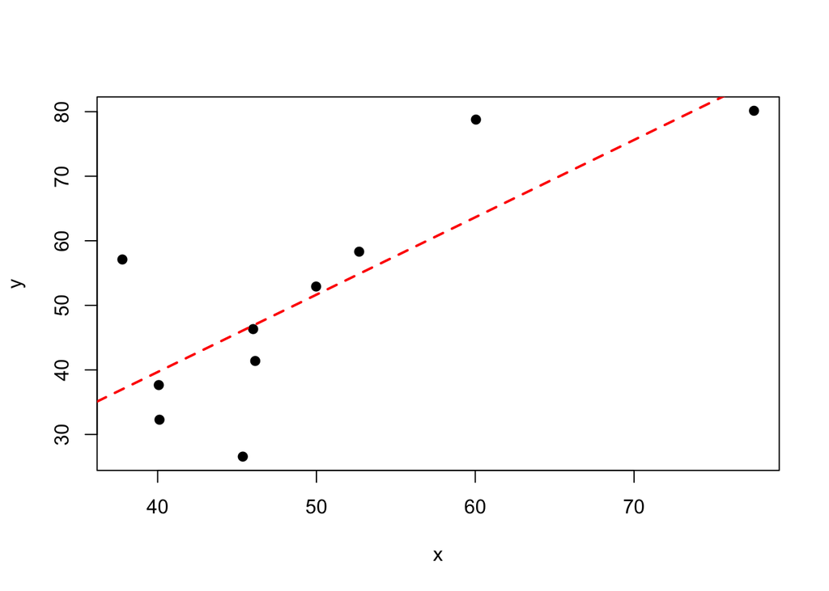

```r
# plot the two variables with the regression line
plot(x, y, pch = 19)
abline(fit, col = "red", lwd = 2, lty = 2)
```

## Simulating a data set with multiple variables

Frequently, we might have a hypothesis regarding how correlated multiple variables are with each other. The example above produced a relationship of two variables with a direct relationship between them along with some noise. We might want to specify this relationship given a correlation coefficient or covariance between them. Additionally, we might have more than two variables that we want to simulate relationships between.

Both packages have a function for simulating multivariate normal distributions. The primary difference is that the `Sigma` argument in the `MASS` package function, `mvrnorm()`, accepts a covariance matrix while the `sigma` argument in the `mvtnorm` package, `rmvnorm()` accepts a correlation matrix. I’ll show both examples but I tend to stick with the `mtvnorm` package because (at least for my brain) it is easier for me to think in terms of correlation coefficients instead of covariances.

First we simulate some data:

```r
## create fake data
set.seed(1234)
fake_dat <- data.frame(
  group = rep(c("a", "b", "c"), each = 5),
  x = rnorm(n = 15, mean = 10, sd = 2),
  y = rnorm(n = 15, mean = 30, sd = 10),
  z = rnorm(n = 15, mean = 75, sd = 20)
)

fake_dat
```

```
##    group         x        y         z
## 1      a  7.585869 28.89715  97.04595
## 2      a 10.554858 24.88990  65.48814
## 3      a 12.168882 20.88805  60.81120
## 4      a  5.308605 21.62828  64.97484
## 5      a 10.858249 54.15835  42.41813
## 6      b 11.012112 31.34088  51.64761
## 7      b  8.850520 25.09314  31.39921
## 8      b  8.906736 25.59452  48.18014
## 9      b  8.871096 34.59589  69.11412
## 10     b  8.219924 23.06280  65.68205
## 11     c  9.045615 15.51795 103.98993
## 12     c  8.003227 35.74756  53.62715
## 13     c  8.447492 19.76344  57.89271
## 14     c 10.128918 29.84862  69.38754
## 15     c 11.918988 20.64051  55.11320
```

Look at the correlation and variance between the three numeric variables.

```r
# correlation
round(cor(fake_dat[, -1]), 3)
```

```
##        x      y      z
## x  1.000  0.142 -0.244
## y  0.142  1.000 -0.358
## z -0.244 -0.358  1.000
```

```r
# variance
round(var(fake_dat[, -1]), 3)
```

```
##        x       y       z
## x  3.268   2.389  -8.247
## y  2.389  86.844 -62.346
## z -8.247 -62.346 348.708
```

We can use this information to simulate new x, y, or z variables.

**Simulating x and y with the MASS package**

Remember, for the `MASS` package, the `Sigma` argument is a matrix of covariances for the variables you are simulating from a multivariate normal distribution.

```r
## get a vector of the mean for each variable
variable_means <- apply(X = fake_dat[, c("x", "y")], MARGIN = 2, FUN = mean)

## Get a matrix of the covariance between x and y
variable_sigmas <- var(fake_dat[, c("x", "y")])

## simulate 1000 new x and y variables using the MASS package
set.seed(98)
new_sim <- MASS::mvrnorm(n = 1000, mu = variable_means, Sigma = variable_sigmas)
head(new_sim)
```

```
##              x         y
## [1,] 11.660139 26.608493
## [2,]  9.283437 23.384633
## [3,]  7.669939 21.132194
## [4,]  8.078012  9.764874
## [5,] 10.914285 32.832825
## [6,]  7.694534 37.538788
```

```r
### look at the results relative to the original x and y
## column means
variable_means
```

```
##         x         y
##  9.325406 27.444470
```

```r
apply(X = new_sim, MARGIN = 2, FUN = mean)
```

```
##         x         y
##  9.235083 27.289888
```

```r
## covariance
var(fake_dat[, c("x","y")])
```

```
##          x         y
## x 3.267924  2.388946
## y 2.388946 86.843737
```

```r
var(new_sim)
```

```
##          x         y
## x 3.341810  2.397987
## y 2.397987 84.331736
```

**Simulating x and y with the mtvnorm package**

Different than the `MASS` package, The `rmvnorm()` function from the `mtvnorm` package requires the `sigma` argument to be a correlations matrix.

Let’s repeat the above process with our `fake_dat` and simulate a relationship between `x` and `y`.

```r
## get a vector of the mean for each variable
variable_means <- apply(X = fake_dat[, c("x", "y")], MARGIN = 2, FUN = mean)

## Get a matrix of the correlation between x and y
variable_cor <- cor(fake_dat[, c("x", "y")])

## simulate 1000 new x and y variables using the mvtnorm package
set.seed(98)
new_sim <- mvtnorm::rmvnorm(n = 1000, mean = variable_means, sigma = variable_cor)
head(new_sim)
```

```
##             x        y
## [1,] 9.212177 27.00428
## [2,] 8.510227 25.50135
## [3,] 9.983129 28.56050
## [4,] 8.587853 27.06757
## [5,] 8.798021 27.98490
## [6,] 9.904439 27.88065
```

```r
### look at the results relative to the original x and y
## column means
variable_means
```

```
##         x         y
##  9.325406 27.444470
```

```r
apply(X = new_sim, MARGIN = 2, FUN = mean)
```

```
##         x         y
##  9.330912 27.472255
```

```r
## correlation
cor(fake_dat[, c("x","y")])
```

```
##           x         y
## x 1.0000000 0.1418081
## y 0.1418081 1.0000000
```

```r
cor(new_sim)
```

```
##           x         y
## x 1.0000000 0.1414332
## y 0.1414332 1.0000000
```

So, what is happening here? Both packages produce the same result, one uses a covariance matrix and the other uses a correlation matrix. The kicker here is understanding the relationship between covariance and correlation. Covariance is explaining how two variables vary together, however, its units aren’t on a scale that is directly interpretable to us. But, we can convert the covariance between two variables to a correlation by dividing their covariance by the product of their individual standard deviations.

For example, here is the covariance matrix between `x` and `y` in the fake data set.

```r
cov(fake_dat[, c("x", "y")])
```

```
##          x         y
## x 3.267924  2.388946
## y 2.388946 86.843737
```

The covariance between the two variables is on the off diagonal, 2.389. We can store this in its own element.

```r
cov_xy <- cov(fake_dat[, c("x", "y")])[2,1]
cov_xy
```

```
## [1] 2.388946
```

Let’s store the standard deviation of both `x` and `y` in their own elements to make the equation easier to read.

```r
sd_x <- sd(fake_dat$x)
sd_y <- sd(fake_dat$y)
```

Finally, we calculate the correlation by dividing the covariance by the product of the two standard deviations and check our results by calling the `cor()` function on the two variables.

```r
## covariance to correlation
cov_to_cor <- cov_xy / (sd_x * sd_y)
cov_to_cor
```

```
## [1] 0.1418081
```

```r
## check results with the corr() function
cor(fake_dat[, c("x", "y")])
```

```
##           x         y
## x 1.0000000 0.1418081
## y 0.1418081 1.0000000
```

**What about three variables?**

What if we want to simulate all three variables – x, y, and z?

All we need is a larger covariance or correlation matrix, depending on which of the above packages you’d like to use. Since we usually won’t be creating these matrices from a data set, as I did above, I’ll show how to create your own matrix and run the simulation.

First, let’s store a vector of plausible mean values for x, y, and z.

```r
## Look at the mean values we had in the fake data
apply(X = fake_dat[, c("x", "y", "z")], MARGIN = 2, FUN = mean)
```

```
##         x         y         z
##  9.325406 27.444470 62.451460
```

```r
## create a vector of possible mean values for the simulation
mus <- c(9, 26, 63)

## look at the correlation matrix for the three variables in the fake data
cor(fake_dat[, c("x", "y", "z")])
```

```
##            x          y          z
## x  1.0000000  0.1418081 -0.2443170
## y  0.1418081  1.0000000 -0.3582666
## z -0.2443170 -0.3582666  1.0000000
```

```r
## Create a matrix that stores plausible correlations between the variables you want to simulate
r_matrix <- matrix(c(1, 0.14, -0.24,
                    0.14, 1, -0.35,
                    -0.24, -0.35, 1),
                   nrow = 3, ncol = 3,
       dimnames = list(c("x", "y", "z"),
                       c("x", "y", "z")))

r_matrix
```

```
##       x     y     z
## x  1.00  0.14 -0.24
## y  0.14  1.00 -0.35
## z -0.24 -0.35  1.00
```

```r
## simulate 1000 new x, y, and z variables using the mvtnorm package
set.seed(43)
new_sim <- mvtnorm::rmvnorm(n = 1000, mean = mus, sigma = r_matrix)
head(new_sim)
```

```
##           [,1]     [,2]     [,3]
## [1,]  8.924015 24.53536 62.80471
## [2,]  9.438696 25.18825 62.83273
## [3,]  9.459371 26.08409 62.29469
## [4,]  7.332317 27.82622 61.96126
## [5,]  8.651035 26.96733 63.40117
## [6,] 11.327872 27.85787 60.88786
```

```r
### look at the results relative to the original x, y, and z
## column means
apply(X = fake_dat[, c("x", "y", "z")], MARGIN = 2, FUN = mean)
```

```
##         x         y         z
##  9.325406 27.444470 62.451460
```

```r
apply(X = new_sim, MARGIN = 2, FUN = mean)
```

```
## [1]  9.011426 26.026274 62.985432
```

```r
## correlation
cor(fake_dat[, c("x", "y", "z")])
```

```
##            x          y          z
## x  1.0000000  0.1418081 -0.2443170
## y  0.1418081  1.0000000 -0.3582666
## z -0.2443170 -0.3582666  1.0000000
```

```r
cor(new_sim)
```

```
##            [,1]       [,2]       [,3]
## [1,]  1.0000000  0.1186565 -0.2201538
## [2,]  0.1186565  1.0000000 -0.3145720
## [3,] -0.2201538 -0.3145720  1.0000000
```